# Лабораторна робота №2. Робота в середовищі Anaconda

## **Тема. Налаштування та робота в середовищі Anaconda+Quarto**

## **Мета:** швидкий старт для роботи в середовищі Anaconda із застосуванням Jupyter Notebook, або Jupyter Notebook засобами мови програмування Python та видавничої системи Quarto.

## Хід роботи

#### 5) Подати в робочому документі виконання пунктів 1-3 індивідуального завдання

- Завантажую і встановлюю збірку Python Anaconda.

[figure not shown]

[figure not shown]

- Через інтерфейс командного рядка налаштувую за допомогою conda віртуальне середовище з ім’ям _OpenCV.

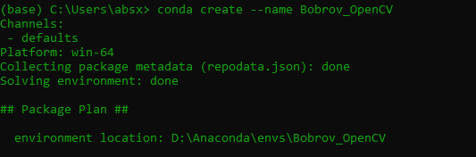

- Інсталюю у створене середовище пакети, необхідні для роботи з OpenCV

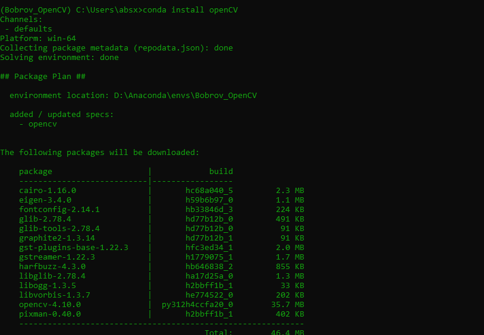

#### 6) Надати відповіді на контрольні запитання

1. Що таке pip і conda та чим вони відрізняються між собою?

*pip — це пакетний менеджер для встановлення Python-бібліотек з PyPI, а conda — універсальний менеджер пакетів і середовищ, який підтримує Python і інші мови, маючи власний репозиторій; основна відмінність у широті можливостей та сумісності з залежностями.*

2. Як буде виглядати виконання пунктів 1–3 індивідуального завдання за допомогою Virtualenv?

*Virtualenv є частиною Python, а Conda вимагає окремого встановлення*

3. Сфотографувати себе на телефон та імпортувати свое зображення у форматі .png

[figure not shown]

```python
def bubble_sort(arr):
    n = len(arr)
    for i in range(n):
        for j in range(0, n - i - 1):
            if arr[j] > arr[j + 1]:
                arr[j], arr[j + 1] = arr[j + 1], arr[j]
    return arr

arr = [14, 42, 29, 94, 71, 50, 88]
print("Вихідний масив:", arr)
bubble_sort(arr)
print("Відсортований масив:", arr)
```

```
Вихідний масив: [14, 42, 29, 94, 71, 50, 88]
Відсортований масив: [14, 29, 42, 50, 71, 88, 94]
```

5. Як виконати компіляцію вхідного документа Jupyter Notebook із його середовища, не використовуючи інтерфейс командного рядка?

*File -> Save And Export Notebook As -> HTML (Або інший тип)*

6. Як виконати компіляцію вхідного документа у Quarto?

*Написати у командному рядку quarto render name*